# Simulation-based power analysis for $N = 1$ intensive longitudinal designs

Authors

Ginette Lafit

Jordan Revol

Published

June 8, 2023

## Settings things up

Before we proceed, we need to ensure we have several packages installed and loaded into our `R` session. For the scripts below, we will use the following packages:

- [`data.table`](https://CRAN.R-project.org/package=data.table)
- [`psych`](https://CRAN.R-project.org/package=psych)
- [`tidyverse`](https://CRAN.R-project.org/package=tidyverse)
- [`MASS`](https://CRAN.R-project.org/package=MASS)
- [`stringr`](https://CRAN.R-project.org/package=stringr)

Which we can install in one go as follows:

```r
# Prepare the package list.
packages = c("data.table", "psych", "tidyverse", "MASS", "stringr")

# Install packages.
install.packages(packages)
```

**Tip**

Now that we have all packages installed, we continue by loading them.

```r
# To create lagged outcome variables.
library(data.table)

# To compute descriptive statistics.
library(psych)

# A useful package.
library(tidyverse)

# Handy functions for data analysis.
library(MASS)

# For handy string manipulation.
library(stringr)

# Set a seed for reproducibility.
set.seed(123)
```

## Preparing the simulation functions

We need two functions to conduct a simulation-based power analysis.

- one function that generates the datasets for the simulation
- and a second function that runs the Monte Carlo simulation to estimate the *empirical power*

### The data generating function

This function generates a dataset from an $\text{VAR}(1)$ model and takes a few arguments as follows:

- `vars` is the number of variables of the $\text{VAR}(1)$ model
- `Tobs` is the number of repeated measurements
- `delta` the intercept matrix
- `psi` the transition matrix (i.e., containing the auto-regressive and cross-regressive effects)
- `sigma` the variance-covariance matrix of the innovation

```r
# Function to generate data from a `VAR(1)` model.
sim_VAR_data <- function(vars, Tobs, delta, psi, sigma) {
    # Number of burning observations.
    T.burning <- 10000

    # Define the number of observations.
    T.total <- T.burning + Tobs

    # Simulate errors.
    if (vars == 1) {
        E <- as.matrix(rnorm(T.total, 0, sigma))
    } else {
        E <- mvrnorm(T.total, mu = rep(0, vars), sigma)
    }

    # Recursive equation.
    Y <- matrix(0, T.total, vars)

    # Initialized values.
    Y[1, ] <- delta + E[1, ]

    # Simulate dependent variables.
    for (t in 2:T.total) {
        Y[t, ] <- delta + psi %*% Y[t - 1, ] + E[t, ]
    }

    # Exclude burning observations.
    Y <- Y[-seq(1:T.burning), ]

    # Create lagged variables.
    Y <- cbind(Y, lag(Y))

    # Rename variables.
    colnames(Y) <- c(
        sprintf("Y%d", seq(1:vars)),
        sprintf("Y%dlag", seq(1:vars))
    )

    # Return the data.
    return(as.data.frame(Y))
}
```

### The Monte Carlo simulation function

This function conducts the Monte Carlo simulation for a set of sample sizes (i.e., several different number of observations) and computes the statistical power for a given hypothesis. It takes several arguments as follows:

- `vars` is the number of variables of the $\text{VAR}(1)$ model
- `Tobs_list` is a list of numbers of repeated measurements (i.e., `Tobs`)
- `delta` the intercept matrix
- `psi` the transition matrix (which contains the auto-regressive and cross-regressive effects)
- `sigma` the variance-covariance matrix of the innovation
- `R` is the number of Monte Carlo replicates (e.g., $1000$)
- `alpha` is the Type I error rate (or significance level of a test statistic)

```r
# Function to conduct the Monte Carlo power simulation.
mc_power <- function(vars, Tobs_list, delta, psi, sigma, R, alpha) {
    # Prepare simulation storage.
    df_pow <- data.frame()

    # For each sample size in the list.
    for (i in 1:length(Tobs_list)) {
        # Extract the sample size.
        Tobs <- Tobs_list[i]

        # Print the progress.
        print(paste0("Power analysis for N = ", Tobs))

        # For each Monte Carlo replication.
        for (r in 1:R) {
            # Generate data.
            data <- sim_VAR_data(vars, Tobs, delta, psi, sigma)

            # Create names lists.
            var_names <- sprintf("Y%d", seq(1:vars))
            lag_names <- sprintf("Y%dlag", seq(1:vars))

            # Prepare storage for the model fits.
            list_pow_rep <- list()

            # For each variable in the model.
            for (nbName in 1:length(var_names)) {
                # Extract variable name.
                name_ <- var_names[nbName]

                # Create the formula for the linear regression.
                formula <- as.formula(
                    paste(name_, paste(lag_names, collapse = " + "), sep = " ~ ")
                )

                # Estimate model.
                model <- lm(formula, data)

                # Extract the coefficients.
                coefficients <- summary(model)$coefficients

                # Extract the `p` values.
                df_pval <- as.data.frame(rbind(coefficients[, 4]))

                # Compute the empirical power.
                list_pow_rep[[nbName]] <- as.data.frame(df_pval < alpha)

                # Add names to the columns.
                names(list_pow_rep[[nbName]]) <- c(
                    paste0("pow_int_", name_),
                    paste0("pow_", lag_names, "_", name_)
                )
            }

            # Bind the columns.
            rep_data <- bind_cols(
                data.frame(Tobs = Tobs), do.call(cbind, list_pow_rep)
            )

            # Bind the rows.
            df_pow <- rbind(df_pow, rep_data)
        }
    }

    # Compute empirical power.
    df_pow <- aggregate(
        df_pow[, 2:ncol(df_pow)], list(df_pow$Tobs), mean
    )

    # Rename the columns.
    df_pow <- rename(df_pow, Tobs = Group.1)

    return(df_pow)
}
```

## Conducting the simulation power analysis

To conduct the simulation-based power analysis you first need to set the following arguments:

- `Tobs`: list of numbers of repeated measurements.
- `vars`: number of variables of the $\text{VAR}(1)$ model.
- `delta`: a $\text{vars} \times 1$ matrix with one intercept per variable.
- `psi`: a $\text{vars} \times \text{vars}$ matrix. The diagonal elements are the autoregressive coefficients, and the off-diagonal are the cross-regressive coefficients.
- `sigma`: a $\text{vars} \times \text{vars}$ matrix. The diagonal elements are the variance of the residuals, and the off-diagonal elements are the covariance values. Note that the matrix should be symmetric.
- `alpha`: type I error rate (i.e., conventionally set at $.05$).
- `R`: the number of Monte Carlo replicates (i.e., $1000$).
- `pow_target`: the empirical power targeted, which is often $.8$. This variable is only used in the results (not in the simulation).

For the reminder of this document, we demonstrate how to run a simulation-based power analysis for the $\text{AR}(1)$ and $\text{VAR}(1)$ models.

### Simulation for the $\text{AR}(1)$ model

We ran a simulation for an $\text{AR}(1)$ model with $\text{Tobs} = \{50, 100, 150\}$, specified as follows:

$$y_{t} = 3 + .3 * y_{t-1} + \varepsilon$$

with:

$$\varepsilon \sim N(0, 10)$$

**Important**

In the example below we set the number of Monte Carlo replicates to `R = 10` to speed up the computation and the generation of this document. In practice, you should set **at lest** `R = 1000` to obtain reliable results. Make sure to change it accordingly when you run the code.

```r
# Specify the simulation inputs.
Tobs_list <- c(50, 100, 150)
vars <- 1
delta <- as.matrix(3)
psi <- as.matrix(.3)
sigma <- as.matrix(10)
alpha <- 0.05
R <- 10
pow_target <- .8

# Run the power analysis simulation.
df_pow_result <- mc_power(vars, Tobs_list, delta, psi, sigma, R, alpha)
```

```
[1] "Power analysis for N = 50"
[1] "Power analysis for N = 100"
[1] "Power analysis for N = 150"
```

With the simulation completed, we can continue to display the results of the power analysis in a plot and a recapitulation table.

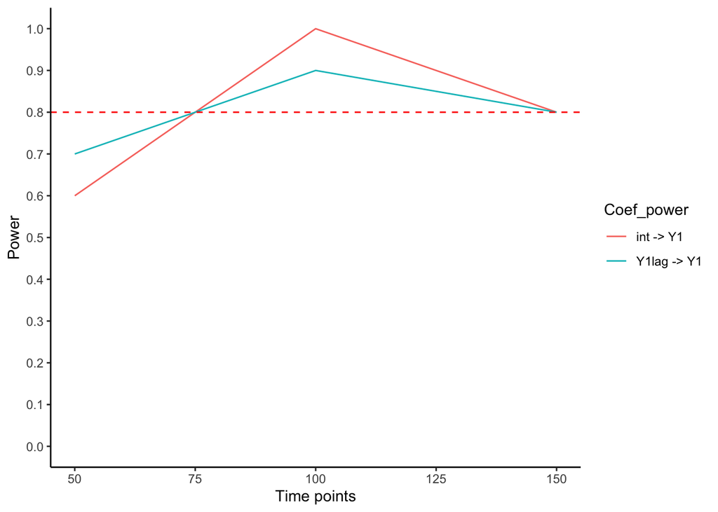

```r
# Prepare the results data for the plot.
dt <- df_pow_result %>%
    gather(Coef_power, power, starts_with("pow"))

# Rename.
dt$Coef_power = stringr::str_replace_all(
    dt$Coef_power, c("pow_" = "", "_" = " -> ")
)

# Plot the results of the `AR(1)` power analysis.
ggplot(dt,
    aes(
        y = power,
        x = Tobs,
        color = Coef_power
    )) +
    geom_line() +
    geom_hline(
        yintercept = pow_target,
        color = "red",
        linetype = 2
    ) +
    scale_y_continuous(
        breaks = seq(0, 1, by = .1),
        limits = c(0, 1)
    ) +
    labs(
        y = "Power",
        x = "Time points"
    ) +
    theme_classic()
```

Finally, we can display the results in a table as shown below.

```r
# Create table of outputs.
dt = df_pow_result %>%
    gather(pow, value, starts_with("pow")) %>%
    spread(Tobs, value)

# Rename variables.
dt$pow <- stringr::str_replace_all(dt$pow, c("pow_"="", "_"=" -> "))

# Rename the columns.
names(dt)[1] <- "Coefficients"

# Print the table.
print(dt)
```

```
  Coefficients  50 100 150
1    int -> Y1 0.6 1.0 0.8
2  Y1lag -> Y1 0.7 0.9 0.8
```

### Simulation for the $\text{VAR}(1)$ model

with:

$$\begin{bmatrix} \varepsilon_{1t} \\ \varepsilon_{2t} \\ \varepsilon_{3t} \end{bmatrix} \sim
N \Bigg( \begin{bmatrix} 0 \\ 0 \end{bmatrix} , \begin{bmatrix} 15 \ 3 \ 6 \\ 3 \ 20 \ 9 \\ 6 \ 9 \ 18 \end{bmatrix} \Bigg)$$

Let’s start by setting the values for the simulation. Check out the documentation for the `mc_power` function for more details on the inputs.

**Important**

Just like before, in the example below we set the number of Monte Carlo replicates to `R = 10` to speed up the computation and the generation of this document. In practice, you should set **at lest** `R = 1000` to obtain reliable results. Make sure to change it accordingly when you run the code.

```r
# Set the values for conducting the power analysis.
Tobs_list = c(50, 100, 150)
vars = 3
delta = as.matrix(c(4, 6, 10))
psi = rbind(
    c(.50, .14, .20),
    c(.10, .40, .03),
    c(.05, .12, .50)
)
sigma = rbind(
    c(15,  3,  6),
    c( 3, 20,  9),
    c( 6,  9, 18)
)
alpha = 0.05
R = 10
pow_target = .8

# Run the power analysis simulation.
df_pow_result <- mc_power(vars, Tobs_list, delta, psi, sigma, R, alpha)
```

```
[1] "Power analysis for N = 50"
[1] "Power analysis for N = 100"
[1] "Power analysis for N = 150"
```

We can continue to display the results of the power analysis in a plot and then summarize them in a table.

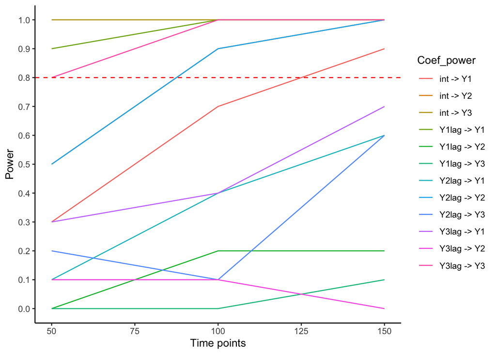

```r
# Prepare the results data for the plot.
dt = df_pow_result %>%
    gather(
        Coef_power, power, starts_with("pow")
    )

# Rename the variables.
dt$Coef_power = stringr::str_replace_all(
    dt$Coef_power, c("pow_" = "", "_" = " -> ")
)

# Plot the results of the power analysis.
ggplot(dt,
    aes(
        y = power,
        x = Tobs,
        color = Coef_power
    )) +
    geom_line() +
    geom_hline(
        yintercept = pow_target,
        color = "red",
        linetype = 2
    ) +
    scale_y_continuous(
        breaks = seq(0, 1, by = .1),
        limits = c(0, 1)
    ) +
    labs(
        y = "Power",
        x = "Time points"
    ) +
    theme_classic()
```

```r
# Create table of outputs.
dt = df_pow_result %>%
    gather(
        pow,
        value,
        starts_with("pow")
    ) %>%
    spread(
        Tobs,
        value
    )

# Rename the variables.
dt$pow <- stringr::str_replace_all(
    dt$pow, c("pow_" = "", "_" = " -> ")
)

# Rename the columns.
names(dt)[1] <- "Coefficients"

# Print the table.
print(dt)
```

```
   Coefficients  50 100 150
1     int -> Y1 0.3 0.7 0.9
2     int -> Y2 0.5 0.9 1.0
3     int -> Y3 1.0 1.0 1.0
4   Y1lag -> Y1 0.9 1.0 1.0
5   Y1lag -> Y2 0.0 0.2 0.2
6   Y1lag -> Y3 0.0 0.0 0.1
7   Y2lag -> Y1 0.1 0.4 0.6
8   Y2lag -> Y2 0.5 0.9 1.0
9   Y2lag -> Y3 0.2 0.1 0.6
10  Y3lag -> Y1 0.3 0.4 0.7
11  Y3lag -> Y2 0.1 0.1 0.0
12  Y3lag -> Y3 0.8 1.0 1.0
```